# Oral Presentation Draft Feedback

CHE 110L: Stage 2 Slides

## Audience

- Another CHE 110 student
- Tell a coherent story

## Slides

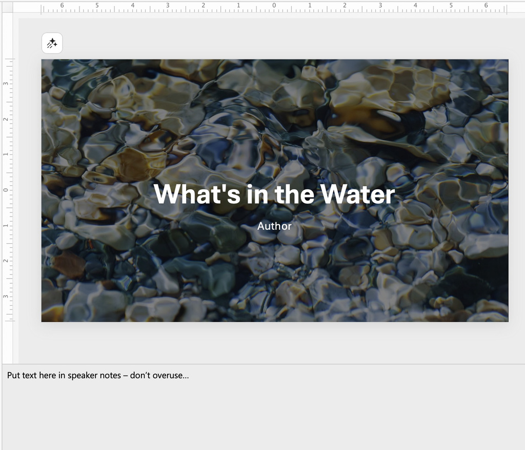

- Words on slides = key points only
- Use the notes box or paper (that you eventually memorize) for more information

## Where the Points Are

|  | Points |
| --- | --- |
| Topical content | 50 |
| PowerPoint slides | 20 |
| Verbal delivery | 30 |

- **Chemistry involved: 14** (the largest single item)

# Content

## Title & Introduction

- Title: descriptive **and** interesting
- Hook: why should we care?
- Just enough background to follow the rest

## Historical Development

- A timeline works well
- A few key dates, not every date
- Don’t stop in the past; bring it up to **today**

## The Chemistry: Pick One Thing and Go Deep

- One or two reactions or structures, not a survey
- **Show it:** a structure, a reaction, a picture of what’s happening
- Make it **big**
- Complicated figure? Take **one piece**, blow it up, explain it
- Explain it so another CHE 110 student can follow

## Roles of Other Experts

- Not a laundry list
- **One or two** experts: who, and exactly what did they contribute?

## Societal Impacts

- Positive **and** negative
- Actual, sourced concerns, not “ethical concerns” or “health risks” in general
- Human health and environment matter more than inconvenience

## Conclusion: don’t just end

- An actual takeaway
- Bigger picture (could connect back to beginning)

## References

- **Numbered** ACS list on a final slide
- Cite the number **on each slide** where you use the source
- **Say** the source out loud when you use it
- Image credit: a basic URL is fine
- AI-use acknowledgement

# Slide Design

## Keep Words to a Minimum

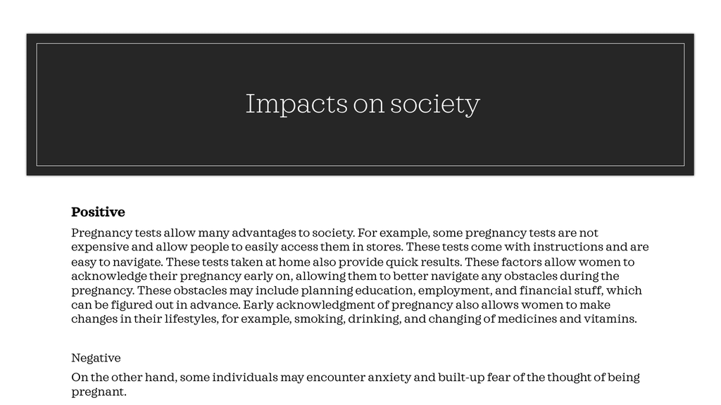

- Your *voice* provides detail
- Sentences → notes box
- ~6 lines per slide; no slide limit, so spread out

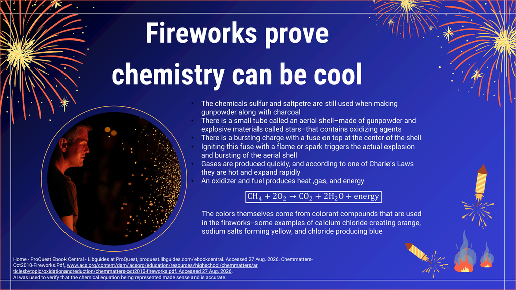

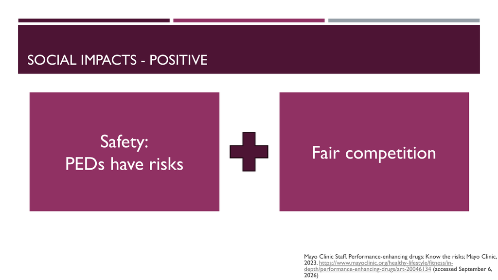

## Make It Bigger

**~24 pt minimum** for everything you want read

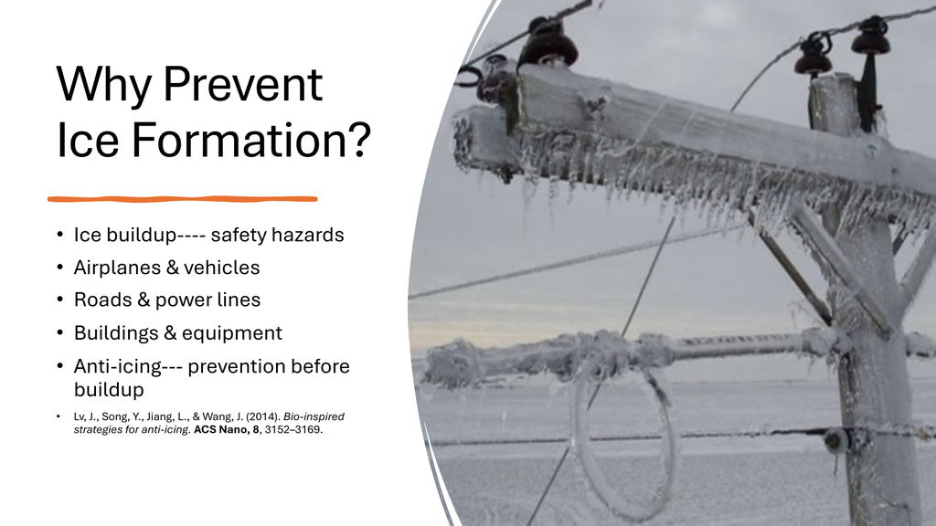

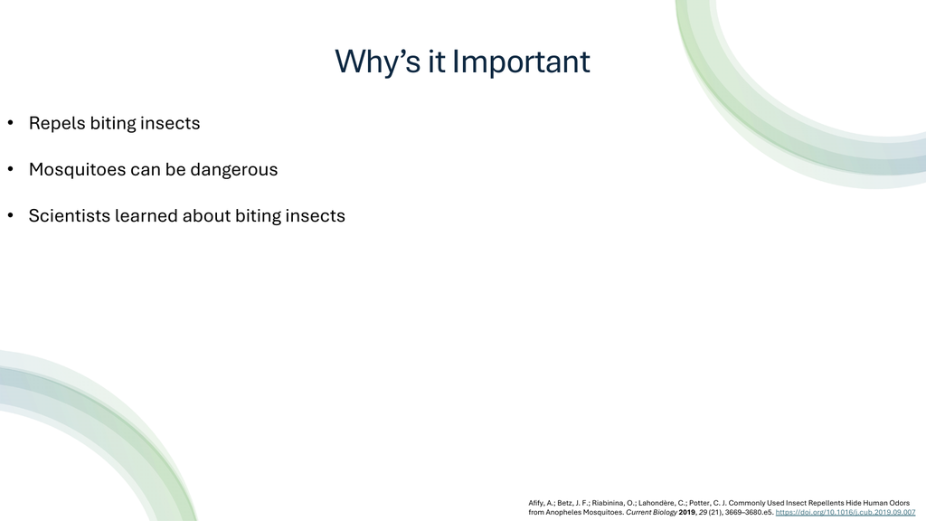

[figure not shown]

## Be Wary: AI-Generated Slides & Graphics

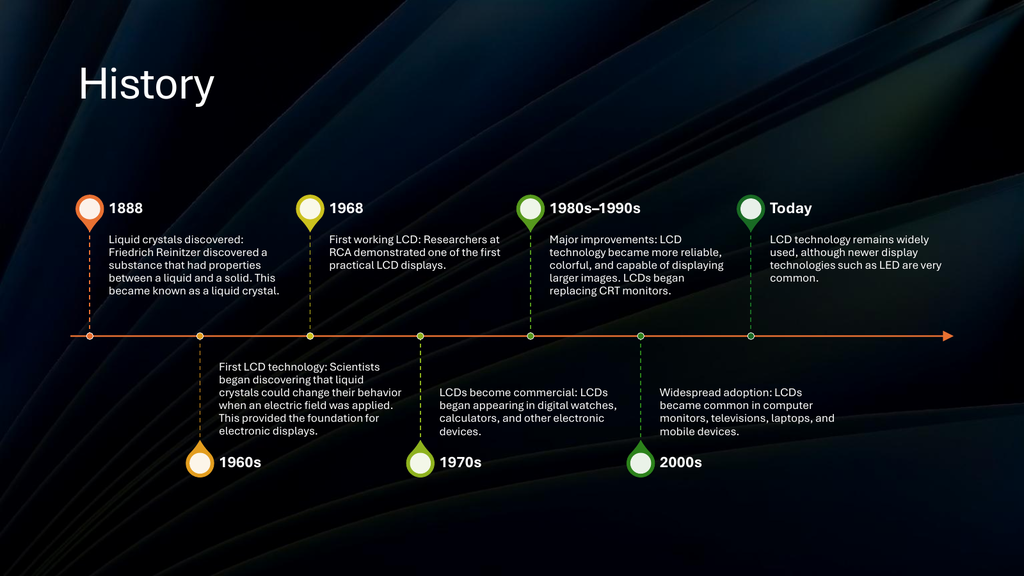

- Looks polished, but the text is **tiny** and in full sentences
- Check every text box: ~24 pt minimum
- Cut words until it fits; don’t shrink the font

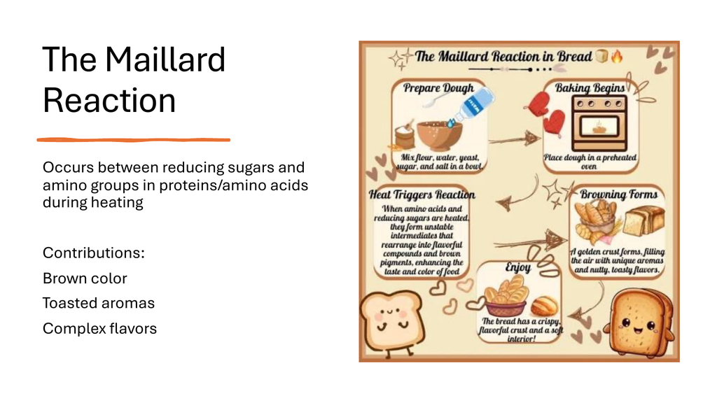

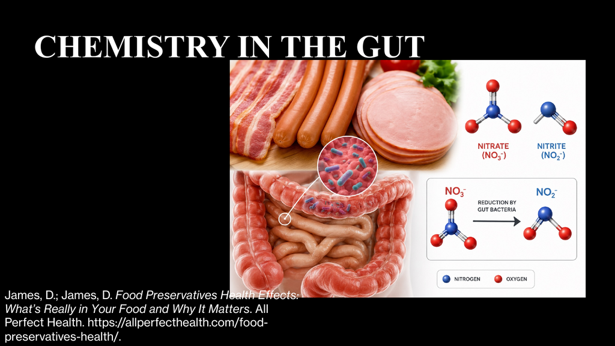

- Text inside a graphic counts too: if the back row can’t read it, crop or redraw

## Readable Colors & Text

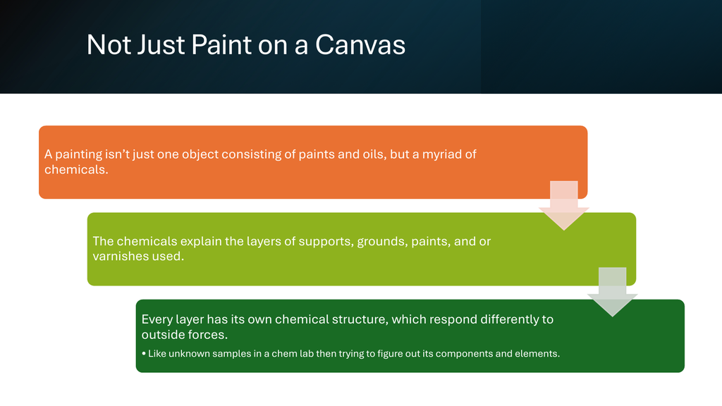

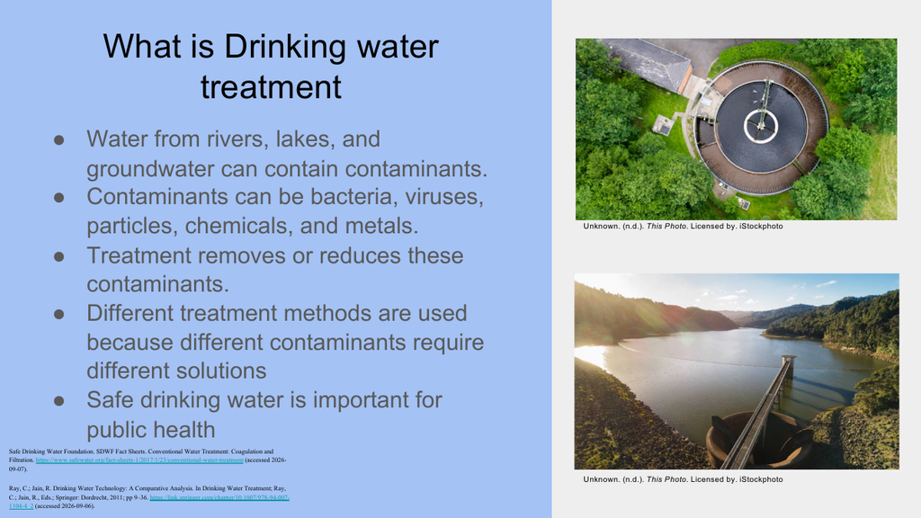

## Proofread!

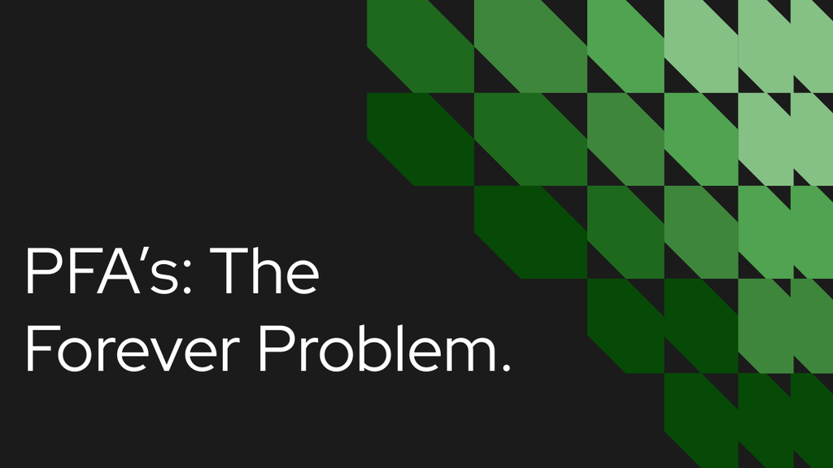

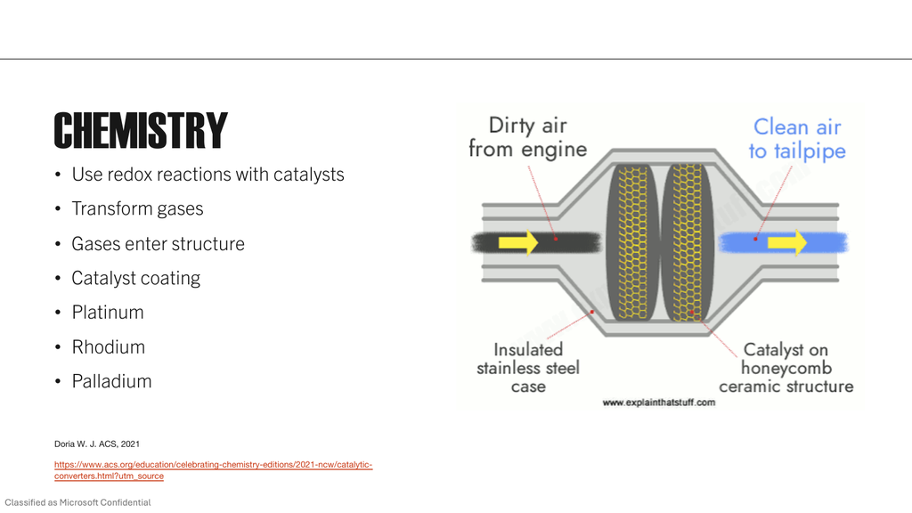

## Inconsistent Theming

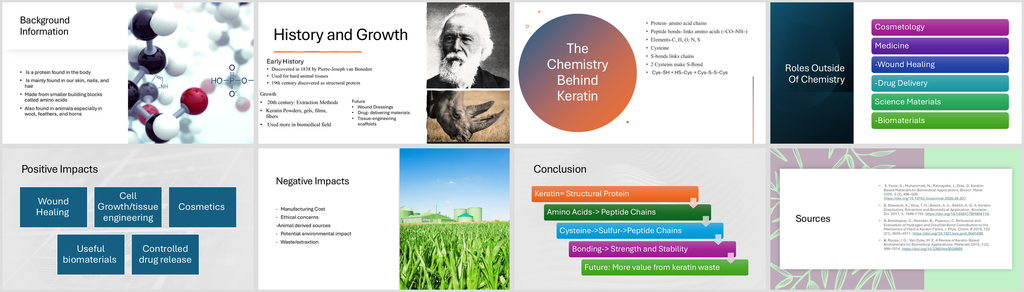

- Pick a theme and stick with it: same fonts, colors, layouts throughout

# Presentation Skills

## Voice & Eye Contact

- **Volume:** loud enough for the room
- **Speed:** don’t rush
- **Eye contact:** audience, not slides
- **Enthusiasm**